# lcibs

Logical Connectives  
in British Statutes

**Contents**

1. Hypothesis
2. An overview of data sources  
   2.1 The legislation.gov.uk API
3. Data quality and pre-processing  
   3.1 Wrangling data  
   3.2 Logical operator definitions
4. Results from investigative analysis of data  
   4.1 Creating a training set  
   4.2 Creating a test set
5. Model development and testing  
   5.1 Training the model and hyperparameter Tuning  
   5.2 Train and evaluate
6. Overview of testing results and final model selection  
   6.1 Evaluation scores  
   6.2 Saving the best model  
   6.3 Results visualisation
7. Hypothesis test and conclusion  
   7.1 Analytics and inferences  
   7.2 Statistcal differences  
   7.3 Conclusion

**Abstract**

This demonstration trains a custom Named-Entity Recognition (NER) model using a convolutional neural network to classify text from a set of logical connectives for use on the UK statute book corpus. The model is used to make inferences on three popular statute documents that are obtained from the www.legislation.gov.uk API and pre-processed. The results are compared to establish whether a significant difference exists between them in terms of thier logical connective complexity.

**1. Hypothesis to test the degree of difference between logical connectives in statutes**

Logical connectives are truth functional with symbolic notation supported by context-free language $L_{1}$. The language can be used to teach an NER learning machnine to classify logical connectives

| $L_{1}$-connective | Word | Term |
| --- | --- | --- |
| P$\wedge$Q | and | Conjunction |
| P$\vee$Q | or | Disjunction |
| P$\neg$Q | not | Negation |
| P$\rightarrow$Q | if...then | Material implication |
| P$\leftrightarrow$Q | if and only if | Bi-conditional |

The constituent parts of a statement may be expressed formally with $L_{1}$-connective sentence letters as with the legislative statement the ‘[Lords Spiritual] **and** [Temporal]’ giving:

$$(\mathbf P_0 \wedge \mathbf Q_0)$$

$\tag{1.1}$

Let $c$ be the number of occurrences for a type $i$ of logical connective in $L_1$ from a class of statute $j$ divided by the number of its words $w$ such that the quotient $q$ is obtained:

$$\begin{equation} q_{i,j}=\frac{c_i}{w_j} \end{equation}$$

$\tag{1.2}$

Thus, each q for $i$ under $j$ can be tabulated $\begin{Bmatrix} q_{i,j} \end{Bmatrix} _{n \times k}$ to produce a dataset for deriving an overall $L_{1}$-connective index or Freidman $F_r$ statistic:

$$Q = \begin{pmatrix} q_{11} & q_{12} & q_{13} & \dots & q_{1n} \\ q_{21} & q_{22} & q_{23} & \dots & q_{2n} \\ q_{k1} & q_{k2} & q_{k3} & \dots & q_{kn} \end{pmatrix}$$

$\tag{1.3}$

Now, to calculate an $L_{1}$-connective index for a statute $j$, let all of its column quotients be summed:

$$\sum_{j=1}^{k} q_j=q_{1} + q_{2} + \cdots + q_{k}$$

$\tag{1.4}$

Furthermore, we obtain $F_r$ after adding rank column $k$ blocks for each treatment row $n$ with the sums named $T$:

$$F_r = \frac{12}{nk(k+1)}(T_{1}^{2} + T_{2}^{2}+\cdots + T_{k}^{2})-3n(k+1)$$

$\tag{1.5}$

The hypotheses then test whether there is a statistical significance between three statutes formed by a dataset $Q$ on an alpha $α$ significance level of 0.05, using probability value $(p)$ under a Friedman testto conclude either:

**$H_{0}$: There is no statistically significant difference in a datset of three groups of statute data in $Q$ such that $p$ > $α$**  
**$H_{1}$: There is a statistically significant difference in a datset of three groups of statute data in $Q$ such that $p$ ≤ $α$**

That is, the null hypothesis $H_{0}$ can be rejected if $p$ ≤ α because the comparative results would show more than a 5% chance of a difference being present where none in fact exists.

**2. The Data Source**

```python
!pip install spacy==2.3.5
!pip install spacy-lookups-data
!python -m spacy download en_core_web_sm
!python -m spacy download en
```

[output not shown]

**2.1 The legislation.gov.uk API**

The model is trained with Law of Property Act 1925 as it offers a wide range of logical connective terms

```python
import requests

data = requests.get("https://www.legislation.gov.uk/ukpga/Geo5/15-16/20/enacted/data.html") #Law of Property Act (1925)
content = data.content
print(content[:3000]) # HTML tags present
```

```
b'\n<!DOCTYPE html\n  SYSTEM "about:legacy-compat">\n<html><head><meta http-equiv="Last-Modified" content="2016-10-05T00:00:00"></meta><meta charset="utf-8"></meta><title>Law of Property Act 1925</title><meta name="description" content="An Act to consolidate the enactments relating to Conveyancing a…
```

**3. Data quality and pre-processing**

**3.1 Wrangling data**

```python
!pip install bs4
```

```
     |████████████████████████████████| 115 kB 1.3 MB/s eta 0:00:01
```

```python
import re
from bs4 import BeautifulSoup
# simplified version
#soup = BeautifulSoup(content)
#clean_content = soup.get_text()
#print(clean_content[500:5000])


# verbose version
def strip_html_tags(text):
    soup = BeautifulSoup(text, "html.parser")
    [s.extract() for s in soup(['iframe', 'script'])]
    stripped_text = soup.get_text()
    stripped_text = re.sub(r'[\r|\n|\r\n]+', '\n', stripped_text)
    return stripped_text

clean_content = strip_html_tags(content)
print(clean_content[500:5000])
```

```
. 7 para. 1(3)(a)s. 216(3)Law of Property Act 1925s. 52(3)Housing and Planning Act 2016Sch. 7 para. 1(3)(b)s. 216(3)Law of Property Act 1925s. 205(1)(xxxviii)Cathedrals Measure 2021Sch. 1 para. 7(c)s. 42(4)4852(1)Law of Property Act 19251925 c. 20An Act to consolidate the enactments relating to Conv…
```

**3.2 Logical operator definitions**

```python
#Import the requisite library
import spacy

#Build upon the spaCy Small Model
nlp = spacy.blank("en")


#Sample text
text = clean_content

#Create the EntityRuler
ruler = nlp.create_pipe("entity_ruler")

#List of Entities and Patterns
ruler.add_patterns([{"label": "(P ∧ Q)", "pattern": "and"},{"label": "(P ∧ Q)", "pattern": "but"},{"label": "(¬ P)", "pattern": "not"},#disregarding material nonimplication"↛"
                    {"label": "(P ∨ Q)", "pattern": "or"},{"label": "(P ← Q)", "pattern": "if"},{"label": "(P ↓ Q)", "pattern": "nor"},#"neither" proceeding "nor"
                    {"label": "(P → Q)", "pattern": "so"},{"label": "(P → Q)", "pattern": "therefore"}])
nlp.add_pipe(ruler)

doc = nlp(text)

#extract entities
for ent in doc.ents[107:180]:
   print (ent.text, ent.label_)
```

```
or (P ∨ Q)
or (P ∨ Q)
not (¬ P)
or (P ∨ Q)
and (P ∧ Q)
and (P ∧ Q)
if (P ← Q)
and (P ∧ Q)
not (¬ P)
or (P ∨ Q)
and (P ∧ Q)
and (P ∧ Q)
or (P ∨ Q)
or (P ∨ Q)
and (P ∧ Q)
and (P ∧ Q)
and (P ∧ Q)
and (P ∧ Q)
and (P ∧ Q)
and (P ∧ Q)
and (P ∧ Q)
and (P ∧ Q)
or (P ∨ Q)
or (P ∨ Q)
or (P ∨ Q)
if (P ← Q)
so (P → Q)
or (P ∨ Q)
or (P ∨ Q)
so (P → Q)
if (P ← Q)
not (¬ P)
but (P ∧ Q)
not (¬ P)
and (P ∧ Q)
if (P ← Q)
or (P ∨ Q)
or (P ∨ Q)
if (P ← Q)
nor (P ↓ Q)
```

[output cut: 18 more lines]

```
or (P ∨ Q)
or (P ∨ Q)
if (P ← Q)
but (P ∧ Q)
or (P ∨ Q)
or (P ∨ Q)
or (P ∨ Q)
not (¬ P)
or (P ∨ Q)
not (¬ P)
or (P ∨ Q)
or (P ∨ Q)
not (¬ P)
or (P ∨ Q)
and (P ∧ Q)
```

**4. Results from investigative analysis of data**

**4.1 Creating a training set**

```python
import spacy

nlp = spacy.load("en_core_web_sm")
text = clean_content
corpus = []

doc = nlp(text)
for sent in doc.sents:
    corpus.append(sent.text)

nlp = spacy.blank("en")

ruler = nlp.create_pipe("entity_ruler")

patterns = [{"label": "(P ∧ Q)", "pattern": "and"},{"label": "(P ∧ Q)", "pattern": "but"},{"label": "(¬ P)", "pattern": "not"},#disregarding material nonimplication"↛"
                    {"label": "(P ∨ Q)", "pattern": "or"},{"label": "(P ← Q)", "pattern": "if"},{"label": "(P ↓ Q)", "pattern": "nor"},#"neither" proceeding "nor"
                    {"label": "(P → Q)", "pattern": "so"},{"label": "(P → Q)", "pattern": "therefore"}]

ruler.add_patterns(patterns)
nlp.add_pipe(ruler)

TRAIN_DATA = []
for sentence in corpus:
    doc = nlp(sentence)
    entities = []

    for ent in doc.ents:
        entities.append([ent.start_char, ent.end_char, ent.label_])
    TRAIN_DATA.append([sentence, {"entities": entities}])

print (TRAIN_DATA[618:640]) #view sample labelled training data LPA (1925)
```

```
[['Second mortgage either by charge by way of legal mortgage or for a term of two thousand years by Frederick Jones to D., to secure three thousand pounds and interest.', {'entities': [[58, 60, '(P ∨ Q)'], [152, 155, '(P ∧ Q)']]}], ['Third mortgage either by charge by way of legal mortgage or for a …
```

**4.2 Creating a test set**

```python
import spacy
import random
import time
import warnings
from spacy.util import minibatch, compounding, decaying
from spacy.gold import GoldParse
from spacy.scorer import Scorer

# Test data is validation data

TEST_DATA = TRAIN_DATA
#TEST_DATA = [['Parliament (Qualification of Women) Act 1918http://www.legislation.gov.uk/ukpga/Geo5/8-9/47/enactedParliament (Qualification of Women)', {'entities': []}], ["Act 1918Members Of ParliamentQueen's Printer of Acts of Parliament2021-02-05Parliament", {'entities': []}], ['(Qualification of Women)', {'entities': []}], ['Act', {'entities': []}], ['19181918 Chapter 47An Act to amend the Law with respect to the Capacity of Women to sit in Parliament.[21st November 1918]Be', {'entities': []}], ["it enacted by the King's most Excellent Majesty, by and with the advice and consent of the Lords Spiritual and Temporal, and Commons, in this present Parliament assembled, and by the authority of the same, as follows:1Capacity of women to be members of Parliament.", {'entities': [[52, 55, '(P ∧ Q)'], [72, 75, '(P ∧ Q)'], [107, 110, '(P ∧ Q)'], [121, 124, '(P ∧ Q)'], [172, 175, '(P ∧ Q)']]}], ['A woman shall not be disqualified by sex or marriage for being elected to or sitting or voting as a Member of the Commons House of Parliament.2Short title.', {'entities': [[14, 17, '(¬ P)'], [41, 43, '(P ∨ Q)'], [74, 76, '(P ∨ Q)'], [85, 87, '(P ∨ Q)']]}], ['This Act may be cited as the Parliament (Qualification of Women) Act, 1918.', {'entities': []}]]

random.seed(0)

# Log files for logging the train and testing scores for references
file = open('output_log.txt','w')
file.write("iteration_no" + "," + "losses" +"\n")

file1 = open('test_output.txt','w')
file1.write("iteration_no"+ "," +"ents_p"+ "," +"ents_r"+ "," +"ents_f"+ "," +"ents_per_type"+ "\n")

file2 = open('train_output.txt','w')
file2.write("iteration_no"+ "," +"ents_p"+ "," +"ents_r"+ "," +"ents_f"+ "," +"ents_per_type"+ "\n")

model = None # ("en_core_web_sm")   # Replace with model to train
start_training_time = time.time()

print("Test set created")
```

```
Test set created
```

**5. Model development and testings**

The training process subscribes to the training pipline taken from spaCy.io below:

[figure not shown]

**5.1 Training the model and hyperparameter tuning**

The following hyperparameters are tuned :

| Hyperparameter | Function | Tuned |
| --- | --- | --- |
| dropout_from | Initial dropout rate | 0.8 |
| dropout_decay | Rate of dropout change 0 = unlimited | 1e-6 |
| token_vector_width | Width of embedding tables and convolutional layers | 256 |
| Conv_depth | Depth of the tok2vec layer | 16 |

```python
def train_spacy(TRAIN_DATA, iterations):

    if model is not None:
        nlp = spacy.load(model)  # load existing spaCy model
        print("Loaded model '%s'" % model)
    else:
        nlp = spacy.blank("en")  # create blank Language class
        print("Created blank 'en' model")

   # TRAIN_DATA = data

    # create the built-in pipeline components and add them to the pipeline
    # nlp.create_pipe works for built-ins that are registered with spaCy
    if 'ner' not in nlp.pipe_names:
        ner = nlp.create_pipe('ner')
        nlp.add_pipe(ner, last=True)

    else:
        ner = nlp.get_pipe("ner")

    # add labels
    for _, annotations in TRAIN_DATA:
         for ent in annotations.get('entities'):
            ner.add_label(ent[2])

    if model is None:
        optimizer = nlp.begin_training()

        # For training with customized cfg
        nlp.entity.cfg['conv_depth'] = 16
        nlp.entity.cfg['token_vector_width'] = 256
        # nlp.entity.cfg['bilstm_depth'] = 1
        # nlp.entity.cfg['beam_width'] = 2


    else:
        print ("resuming")
        optimizer = nlp.resume_training()
        print (optimizer.learn_rate)

    # get names of other pipes to disable them during training
    pipe_exceptions = ["ner", "trf_wordpiecer", "trf_tok2vec"]
    other_pipes = [pipe for pipe in nlp.pipe_names if pipe != 'ner']

    dropout = decaying(0.8, 0.2, 1e-6) #minimum, max, decay rate
    sizes = compounding(1.0, 4.0, 1.001)

    with nlp.disable_pipes(*other_pipes):  # only train NER

        warnings.filterwarnings("once", category=UserWarning, module='spacy')

        for itn in range(iterations):

            file = open('outputlog.txt','a') # For logging losses of iterations

            start = time.time() # Iteration Time

            if(itn%100 == 0):
                print("Itn  : "+str(itn), time.time()-start_training_time)
                print('Testing')

                results = evaluate(nlp, TEST_DATA)
                file1 = open('test_output.txt','a')
                file1.write(str(itn)+','+ str(results['ents_p'])+','+str(results['ents_r'])+','+str(results['ents_f'])+','+str(results["ents_per_type"])+"\n")
                file1.close()

                results = evaluate(nlp, TRAIN_DATA)
                file2 = open('train_output.txt','a')
                file2.write(str(itn)+','+ str(results['ents_p'])+','+str(results['ents_r'])+','+str(results['ents_f'])+','+str(results["ents_per_type"])+"\n")
                file2.close()

                modelfile = "training_model"+str(itn)
                nlp.to_disk(modelfile)

            # Reducing Learning rate after certain operations
            if (itn == 500):
                optimizer.learn_rate = 0.0001

            print("Starting iteration " + str(itn))
            random.shuffle(TRAIN_DATA)
            losses = {}

            # use either batches or entire set at once

            ##### For training in Batches
            batches = minibatch(TRAIN_DATA, size=sizes)
            for batch in batches:
                texts, annotations = zip(*batch)
                nlp.update(texts, annotations, sgd=optimizer, drop=next(dropout), losses=losses)

            ###########################################

            ##### For training in as a single iteration

            #for text, annotations in TRAIN_DATA:
                 #nlp.update(
                         #[text],  # batch of texts
                         #[annotations],  # batch of annotations
                         #drop=0.2,  # dropout - make it harder to memorise data
                         ## drop=next(dropout),  Incase you are using decaying drop
                         #sgd=optimizer,  # callable to update weights
                         #losses=losses)


            print("Losses",losses)
            file.write(str(itn) + "," + str(losses['ner']) +"\n")
            print ("time for iteration:", time.time()-start)
            file.close()

    return nlp

print("Training code and hyperparameters set")
```

```
Training code and hyperparameters set
```

**5.2 Train and evaluate**

```python
def evaluate(ner_model, test_data):
    scorer = Scorer()
    for input_, annot in test_data:
        doc_gold_text = ner_model.make_doc(input_)
        gold = GoldParse(doc_gold_text, entities=annot['entities'])
        pred_value = ner_model(input_)
        scorer.score(pred_value, gold)
    return scorer.scores
print("Evaluation class created")
```

```
Evaluation class created
```

```python
prdnlp = train_spacy(TRAIN_DATA, 20) #testing 20 epochs
```

```
Created blank 'en' model
Itn  : 0 11.242006778717041
Testing
Starting iteration 0
Losses {'ner': 13434.728009529337}
time for iteration: 54.9470853805542
Starting iteration 1
Losses {'ner': 6243.343658795353}
time for iteration: 20.934734582901
Starting iteration 2
Losses {'ner': 4651.226083820956}
time for iteration: 16.14111351966858
Starting iteration 3
Losses {'ner': 4417.386606353655}
time for iteration: 14.486966848373413
Starting iteration 4
Losses {'ner': 4085.5818656755528}
time for iteration: 14.27464771270752
Starting iteration 5
Losses {'ner': 3395.0369291755496}
time for iteration: 14.500413656234741
Starting iteration 6
Losses {'ner': 2610.7954757295347}
time for iteration: 14.354066848754883
Starting iteration 7
Losses {'ner': 2273.2595140737494}
time for iteration: 14.79442024230957
Starting iteration 8
Losses {'ner': 1911.6350481376005}
time for iteration: 14.672713994979858
Starting iteration 9
Losses {'ner': 1690.7168209592996}
time for iteration: 14.790572881698608
Starting iteration 10
Losses {'ner': 1619.1380177262959}
time for iteration: 14.688693046569824
Starting iteration 11
Losses {'ner': 1435.9242302437137}
time for iteration: 14.800071477890015
Starting iteration 12
```

[output cut: 8 more lines]

```
Starting iteration 15
Losses {'ner': 1251.3054363719368}
time for iteration: 14.408371448516846
Starting iteration 16
Losses {'ner': 1122.129048868239}
time for iteration: 14.615769863128662
Starting iteration 17
Losses {'ner': 1027.3308676682389}
time for iteration: 15.617067575454712
Starting iteration 18
Losses {'ner': 974.936043011914}
time for iteration: 16.259764671325684
Starting iteration 19
Losses {'ner': 1017.9710930895743}
time for iteration: 16.3823082447052
```

**6. Overview of testing results and final model selection**

**6.1 Evaluation scores**

[output not shown]

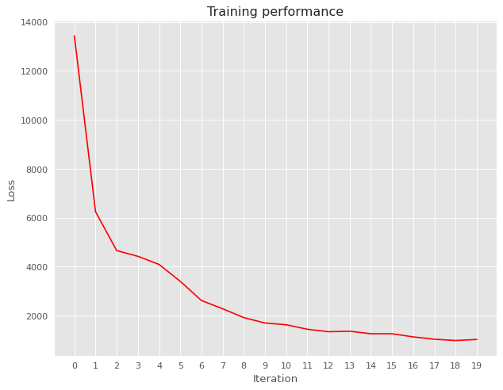

```python
import matplotlib
import matplotlib.pyplot as plt
import numpy as np
from matplotlib.pyplot import figure
matplotlib.style.use('ggplot')
figure(num=None, figsize=(9, 7), dpi=80, facecolor='w', edgecolor='k')

data = np.genfromtxt('./outputlog.txt', delimiter=",", names=["x", "y"])
plt.title('Training performance')
plt.xlabel("Iteration")
plt.ylabel("Loss")

plt.plot(data['x'], data['y'], 'r')
plt.xticks(range(0,20))
#plt.savefig('line_plot.pdf')
# https://stackoverflow.com/questions/52229875/how-to-force-matplotlib-to-show-values-on-x-axis-as-integers
```

```python
# test_text = input("Enter your testing text: ")
# doc = prdnlp(test_text)
# for ent in doc.ents:
#     print(ent.text, ent.start_char, ent.end_char, ent.label_)

# Prints Final -- f1 score, precision and recall
results = evaluate(prdnlp, TEST_DATA)
import json
print (json.dumps(results,indent=4))
```

```
{
    "uas": 0.0,
    "las": 0.0,
    "las_per_type": {
        "": {
            "p": 0.0,
            "r": 0.0,
            "f": 0.0
        }
    },
    "ents_p": 97.26979820247583,
    "ents_r": 97.28629579375848,
    "ents_f": 97.27804629865174,
    "ents_per_type": {
        "(P \u2228 Q)": {
            "p": 95.72281167108754,
            "r": 100.0,
            "f": 97.8146705065221
        },
        "(\u00ac P)": {
            "p": 94.91525423728814,
            "r": 100.0,
            "f": 97.39130434782608
        },
        "(P \u2227 Q)": {
            "p": 99.94655264564403,
            "r": 100.0,
            "f": 99.9732691793638
        },
        "(P \u2192 Q)": {
            "p": 100.0,
            "r": 36.45320197044335,
            "f": 53.42960288808665
        },
        "(P \u2190 Q)": {
            "p": 99.71098265895954,
            "r": 98.29059829059828,
            "f": 98.99569583931132
        },
        "(P \u2193 Q)": {
            "p": 0.0,
            "r": 0.0,
            "f": 0.0
        }
    },
    "tags_acc": 0.0,
    "token_acc": 100.0,
    "textcat_score": 0.0,
    "textcats_per_cat": {}
}
```

**6.2 Saving the best model and testing a statute**

```python
!pip install bs4
```

Using the Employment Rights Act (ERA) 1996 as test data

```python
import requests

statute = requests.get("https://www.legislation.gov.uk/ukpga/1996/18/enacted/data.html") #Employment Rights Act 1996
content = statute.content
from bs4 import BeautifulSoup

soup = BeautifulSoup(content)
clean_statute = soup.get_text()
print(clean_statute[50000:52500])
```

```
of whatever nature.5For the purposes of this Part any monetary value attaching to any payment or benefit in kind furnished to a worker by his employer shall not be treated as wages of the worker except in the case of any voucher, stamp or similar document which is—aof a fixed value expressed in mone…
```

Make inferences on the ERA 1996

```python
#inference - cross-validation on unseen data

text = clean_statute
doc_ERA_data = prdnlp(text)

for ent in doc_ERA_data.ents:
    print (ent.text, ent.label_)
```

```
and (P ∧ Q)
and (P ∧ Q)
and (P ∧ Q)
and (P ∧ Q)
and (P ∧ Q)
and (P ∧ Q)
and (P ∧ Q)
and (P ∧ Q)
and (P ∧ Q)
and (P ∧ Q)
and (P ∧ Q)
and (P ∧ Q)
and (P ∧ Q)
and (P ∧ Q)
and (P ∧ Q)
and (P ∧ Q)
and (P ∧ Q)
and (P ∧ Q)
and (P ∧ Q)
and (P ∧ Q)
and (P ∧ Q)
and (P ∧ Q)
and (P ∧ Q)
and (P ∧ Q)
and (P ∧ Q)
and (P ∧ Q)
and (P ∧ Q)
and (P ∧ Q)
and (P ∧ Q)
and (P ∧ Q)
and (P ∧ Q)
and (P ∧ Q)
and (P ∧ Q)
and (P ∧ Q)
and (P ∧ Q)
and (P ∧ Q)
and (P ∧ Q)
and (P ∧ Q)
and (P ∧ Q)
and (P ∧ Q)
```

[output cut: 3510 more lines]

```
and (P ∧ Q)
and (P ∧ Q)
and (P ∧ Q)
and (P ∧ Q)
and (P ∧ Q)
and (P ∧ Q)
and (P ∧ Q)
and (P ∧ Q)
and (P ∧ Q)
and (P ∧ Q)
and (P ∧ Q)
and (P ∧ Q)
or (P ∨ Q)
92(5 (P ∨ Q)
92(5 (P ∨ Q)
```

```python
#Count the entities

# Check other text that might have been incorretly counted

from collections import Counter

# Create a list
z = [(ent.text, ent.label_) for ent in doc_ERA_data.ents]
col_count = Counter(z)
print(col_count)
```

```
Counter({('or', '(P ∨ Q)'): 1497, ('and', '(P ∧ Q)'): 954, ('not', '(¬ P)'): 592, ('if', '(P ← Q)'): 312, ('so', '(P ∨ Q)'): 100, ('but', '(P ∧ Q)'): 72, ('so', '(P → Q)'): 32, ('nor', '(¬ P)'): 3, ('92(5', '(P ∨ Q)'): 2, ('it.4In', '(P ∧ Q)'): 1})
```

```python
# Save trained Model

# uncomment if model name through command line
# modelfile = input("Enter your Model Name: ")
modelfile = "Final_model"
prdnlp.to_disk(modelfile)
print("Saved model to", modelfile)
```

```
Saved model to Final_model
```

**6.3 Results visualisation**

```python
from spacy import displacy
colors = {"(P ∧ Q)":"lightblue", "(¬ P)":"lightgreen","(P ∨ Q)":"orange","(P ← Q)":"purple","(P ↓ Q)":"light red","(P → Q)":"grey"}
options = {"ents": ["(P ∧ Q)", "(¬ P)", "(P ∨ Q)", "(P ← Q)", "(P ↓ Q)", "(P → Q)"], "colors": colors}
displacy.render(doc_ERA_data[15000:20000], style='ent', jupyter=True, options=options)
```

out shop worker, orba protected betting worker or (P ∨ Q) an opted-out betting worker,has the right not (¬ P) to be subjected to any detriment by any act, or (P ∨ Q) any deliberate failure to act, by his employer done on the ground that the employee refused ( or (P ∨ Q) proposed to refuse) to do shop work, or (P ∨ Q) betting work, on Sunday or (P ∨ Q) on a particular Sunday.2Subsection (1) does not (¬ P) apply to anything done in relation to an opted-out shop worker or (P ∨ Q) an opted-out betting worker on the ground that he refused ( or (P ∨ Q) proposed to refuse) to do shop work, or (P ∨ Q) betting work, on any Sunday or (P ∨ Q) Sundays falling before the end of the notice period.3An employee who is a shop worker or (P ∨ Q) a betting worker has the right not (¬ P) to be subjected to any detriment by any act, or (P ∨ Q) any deliberate failure to act, by his employer done on the ground that the employee gave ( or (P ∨ Q) proposed to give) an opting-out notice to his employer.4Subsections (1) and (P ∧ Q) (3) do not (¬ P) apply where the detriment in question amounts to dismissal (within the meaning of Part X).5For the purposes of this section a shop worker or (P ∨ Q) betting worker who does not (¬ P) work on Sunday or (P ∨ Q) on a particular Sunday is not (¬ P) to be regarded as having been subjected to any detriment by—aa failure to pay remuneration in respect of shop work, or (P ∨ Q) betting work, on a Sunday which he has not (¬ P) done,ba failure to provide him with any other benefit, where that failure results from the application (in relation to a Sunday on which the employee has not (¬ P) done shop work, or (P ∨ Q) betting work) of a contractual term under which the extent of that benefit varies according to the number of hours worked by the employee or (P ∨ Q) the remuneration of the employee, orca failure to provide him with any work, remuneration or (P ∨ Q) other benefit which by virtue of section 38 or (P ∨ Q) 39 the employer is not (¬ P) obliged to provide.6Where an employer offers to pay a sum specified in the offer to any one or (P ∨ Q) more employees—awho are protected shop workers or (P ∨ Q) opted-out shop workers or (P ∨ Q) protected betting workers or (P ∨ Q) opted-out betting workers, orbwho under their contracts of employment are not (¬ P) obliged to do shop work, or (P ∨ Q) betting work, on Sunday, if (P ← Q) they agree to do shop work, or (P ∨ Q) betting work, on Sunday or (P ∨ Q) on a particular Sunday subsections (7) and (P ∧ Q) (8) apply.7An employee to whom the offer is not (¬ P) made is not (¬ P) to be regarded for the purposes of this section as having been subjected to any detriment by any failure to make the offer to him or (P ∨ Q) to pay him the sum specified in the offer.8An employee who does not (¬ P) accept the offer is not (¬ P) to be regarded for the purposes of this section as having been subjected to any detriment by any failure to pay him the sum specified in the offer.9For the purposes of section 36(2)(b) or…

```python
!pip install py-readability-metrics
!python -m nltk.downloader punkt
```

Show inference figures

```python
ERA_NEG_count = 0

# Iterate over all the entities
for ent in doc_ERA_data.ents:
    if ("(¬ P)" in ent.label_):  # isues counting (¬ P) when 1
        # Increment count
        ERA_NEG_count += 1

ERA_DSJ_count = 0

# Iterate over all the entities
for ent in doc_ERA_data.ents:
    if ("(P ∨ Q)" in ent.label_):
        # Increment count
        ERA_DSJ_count += 1

ERA_CNJ_count = 0

# Iterate over all the entities
for ent in doc_ERA_data.ents:
    if ("(P ∧ Q)" in ent.label_):
        # Increment count
        ERA_CNJ_count += 1

ERA_MIMP_count = 0

# Iterate over all the entities
for ent in doc_ERA_data.ents:
    if ("(P → Q)" in ent.label_):
        # Increment count
        ERA_MIMP_count += 1

ERA_JD_count = 0

# Iterate over all the entities
for ent in doc_ERA_data.ents:
    if ("(P ↓ Q)" in ent.label_):
        # Increment count
        ERA_JD_count += 1

ERA_CIMP_count = 0

# Iterate over all the entities
for ent in doc_ERA_data.ents:
    if ("(P ← Q)" in ent.label_):
        # Increment count
        ERA_CIMP_count += 1

# Print count
print("(¬ P) =", ERA_NEG_count)
print("(P ∨ Q) =", ERA_DSJ_count)
print("(P ∧ Q) =", ERA_CNJ_count)
print("(P → Q) =", ERA_MIMP_count)
print("(P ↓ Q) =", ERA_JD_count)
print("(P ← Q) =", ERA_CIMP_count)

# using split()
# to count words in string
res = len(text.split())
total_w = res
# printing result
print ("Total number of words = " +  str(total_w))

print ("Total number of logical connectives = " + str(ERA_NEG_count + ERA_DSJ_count + ERA_CNJ_count + ERA_MIMP_count + ERA_JD_count + ERA_CIMP_count))

total_lc = ERA_NEG_count + ERA_DSJ_count + ERA_CNJ_count + ERA_MIMP_count + ERA_JD_count + ERA_CIMP_count
ratio = (total_lc / total_w)
print ("Logical connective count / number of words = " + str(ratio))





from readability import Readability
r = Readability(clean_statute)

f = r.flesch()

print("Flesch score = " + str(f.score) + " " + str(f.ease))

#ERA_lc_quotient = (total_lc / total_w * 100)

#ERA_lc_quotient_rd = str(round(ERA_lc_quotient, 2))

#print (ERA_lc_quotient_rd)
#print (ERA_lc_quotient)

#print ("Logical connective quotient = " + str(round(ERA_lc_quotient, 2)))

###########################

ERA_NEG_quotient = (ERA_NEG_count / total_w)
ERA_DSJ_quotient = (ERA_DSJ_count / total_w)
ERA_CNJ_quotient = (ERA_CNJ_count / total_w)
ERA_MIMP_quotient = (ERA_MIMP_count / total_w)
ERA_JD_quotient = (ERA_JD_count / total_w)
ERA_CIMP_quotient = (ERA_CIMP_count / total_w)

ERA_total_quotient = ERA_NEG_quotient + ERA_DSJ_quotient + ERA_CNJ_quotient + ERA_MIMP_quotient + ERA_JD_quotient + ERA_CIMP_quotient


print ("Negation (¬ P) quotient = " + str(round(ERA_NEG_quotient, 5)))
print ("Disjunction (P ∨ Q) quotient = " + str(round(ERA_DSJ_quotient, 5)))
print ("Conjunction (P ∨ Q) quotient = " + str(round(ERA_CNJ_quotient, 5)))
print ("Material Implication (P → Q) quotient = " + str(round(ERA_MIMP_quotient, 5)))
print ("Joint Denial (P ↓ Q) quotient = " + str(round(ERA_JD_quotient, 5)))
print ("Converse Implication (P ← Q) quotient = " + str(round(ERA_CIMP_quotient, 5)))
print ("Total logical connective quotient = " + str(round(ERA_total_quotient, 2)))
```

```
(¬ P) = 595
(P ∨ Q) = 1599
(P ∧ Q) = 1027
(P → Q) = 32
(P ↓ Q) = 0
(P ← Q) = 312
Total number of words = 73941
Total number of logical connectives = 3565
Logical connective count / number of words = 0.04821411666058073
Flesch score = -17.543156548234023 very_confusing
Negation (¬ P) quotient = 0.00805
Disjunction (P ∨ Q) quotient = 0.02163
Conjunction (P ∨ Q) quotient = 0.01389
Material Implication (P → Q) quotient = 0.00043
Joint Denial (P ↓ Q) quotient = 0.0
Converse Implication (P ← Q) quotient = 0.00422
Total logical connective quotient = 0.05
```

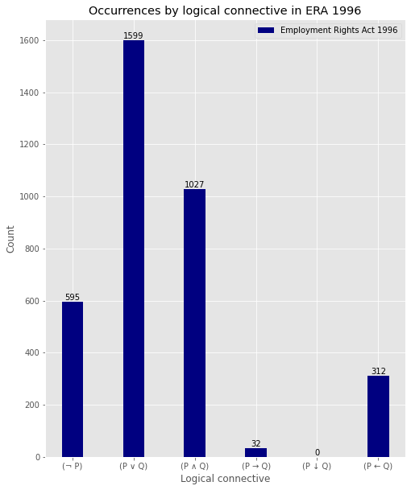

```python
#!/usr/bin/env python
# a bar plot with errorbars
import numpy as np
import matplotlib.pyplot as plt
matplotlib.style.use('ggplot')

data = [("(¬ P)", ERA_NEG_count), ("(P ∨ Q)", ERA_DSJ_count), ("(P ∧ Q)", ERA_CNJ_count), ("(P → Q)", ERA_MIMP_count), ("(P ↓ Q)", ERA_JD_count), ("(P ← Q)", ERA_CIMP_count)]
names, values = zip(*data)
# names = [x[0] for x in data]  # These two lines are equivalent to the the zip-command.
# values = [x[1] for x in data] # These two lines are equivalent to the the zip-command.

ind = np.arange(len(data))  # the x locations for the groups
width = 0.35       # the width of the bars

fig, ax = plt.subplots(figsize=(8,10))
rects1 = ax.bar(ind, values, width, color='navy', label="Employment Rights Act 1996")

# add some text for labels, title and axes ticks
ax.set_ylabel('Count')
ax.set_xlabel('Logical connective')
ax.set_title('Occurrences by logical connective in ERA 1996')
ax.legend()
ax.set_xticks(ind)
ax.set_xticklabels(names)



def autolabel(rects1):
    """Attach a text label above each bar in *rects*, displaying its height."""
    for rect in rects1:
        height = rect.get_height()
        ax.annotate('{}'.format(height),
                    xy=(rect.get_x() + rect.get_width() / 2, height),
                    xytext=(0, 0),  # 3 points vertical offset
                    textcoords="offset points",
                    ha='center', va='bottom')


autolabel(rects1)

plt.savefig("era.pdf")

plt.show()
```

**7. Hypothesis test and conclusion**

Import Freedom of Information Act 2000 (FIA), Data Protection Act 1998 (DPA), and Health and Safety at Work etc. Act 1974 (HSWA).

```python
import requests

statute = requests.get("https://www.legislation.gov.uk/ukpga/2000/36/enacted/data.html") #Freedom of Information Act 2000
FIA = statute.content
from bs4 import BeautifulSoup
soup1 = BeautifulSoup(FIA)
clean_FIA = soup1.get_text()

statute = requests.get("https://www.legislation.gov.uk/ukpga/1998/29/enacted/data.html") #Data Protection Act 1998
DPA = statute.content
from bs4 import BeautifulSoup
soup2 = BeautifulSoup(DPA)
clean_DPA= soup2.get_text()

statute = requests.get("https://www.legislation.gov.uk/ukpga/1974/37/enacted/data.html") #Health and Safety at Work etc. Act 1974
HSWA = statute.content
from bs4 import BeautifulSoup
soup3 = BeautifulSoup(HSWA)
clean_HSWA = soup3.get_text()

print("Statutes imported and cleaned")
```

```
Statutes imported and cleaned
```

**7.1 Analytics and inferences**

Collecting data from interences of the statutes for statistical testing.

```python
FIA_data = clean_FIA
doc_FIA_data = prdnlp(FIA_data)

DPA_data = clean_DPA
doc_DPA_data = prdnlp(DPA_data)

HSWA_data = clean_HSWA
doc_HSWA_data = prdnlp(HSWA_data)

print("Inferences complete")
```

```
Inferences complete
```

```python
FIA_NEG_count = 0

# Iterate over all the entities
for ent in doc_FIA_data.ents:
    if ("(¬ P)" in ent.label_):  # isues counting (¬ P) when 1
        # Increment count
        FIA_NEG_count += 1

FIA_DSJ_count = 0

# Iterate over all the entities
for ent in doc_FIA_data.ents:
    if ("(P ∨ Q)" in ent.label_):
        # Increment count
        FIA_DSJ_count += 1

FIA_CNJ_count = 0

# Iterate over all the entities
for ent in doc_FIA_data.ents:
    if ("(P ∧ Q)" in ent.label_):
        # Increment count
        FIA_CNJ_count += 1

FIA_MIMP_count = 0

# Iterate over all the entities
for ent in doc_FIA_data.ents:
    if ("(P → Q)" in ent.label_):
        # Increment count
        FIA_MIMP_count += 1

FIA_JD_count = 0

# Iterate over all the entities
for ent in doc_FIA_data.ents:
    if ("(P ↓ Q)" in ent.label_):
        # Increment count
        FIA_JD_count += 1

FIA_CIMP_count = 0

# Iterate over all the entities
for ent in doc_FIA_data.ents:
    if ("(P ← Q)" in ent.label_):
        # Increment count
        FIA_CIMP_count += 1


# using split()
# to count words in string
FIA_res = len(FIA_data.split())
FIA_total_w = FIA_res

#total_lc = FIA_NEG_count + FIA_DSJ_count + FIA_CNJ_count + FIA_MIMP_count + FIA_JD_count + FIA_CIMP_count
#FIA_lc_quotient = (total_lc / total_w * 100)

FIA_NEG_quotient = (FIA_NEG_count / FIA_total_w)
FIA_DSJ_quotient = (FIA_DSJ_count / FIA_total_w)
FIA_CNJ_quotient = (FIA_CNJ_count / FIA_total_w)
FIA_MIMP_quotient = (FIA_MIMP_count / FIA_total_w)
FIA_JD_quotient = (FIA_JD_count / FIA_total_w)
FIA_CIMP_quotient = (FIA_CIMP_count / FIA_total_w)

FIA_total_quotient = FIA_NEG_quotient + FIA_DSJ_quotient + FIA_CNJ_quotient + FIA_MIMP_quotient + FIA_JD_quotient + FIA_CIMP_quotient
print("Stats complete")
```

```
Stats complete
```

```python
FIA_total_quotient = FIA_NEG_quotient + FIA_DSJ_quotient  + FIA_CNJ_quotient  + FIA_MIMP_quotient  + FIA_JD_quotient  + FIA_CIMP_quotient
print (FIA_total_quotient)
```

```
0.04462125100828628
```

```python
DPA_NEG_count = 0

# Iterate over all the entities
for ent in doc_DPA_data.ents:
    if ("(¬ P)" in ent.label_):  # isues counting (¬ P) when 1
        # Increment count
        DPA_NEG_count += 1

DPA_DSJ_count = 0

# Iterate over all the entities
for ent in doc_DPA_data.ents:
    if ("(P ∨ Q)" in ent.label_):
        # Increment count
        DPA_DSJ_count += 1

DPA_CNJ_count = 0

# Iterate over all the entities
for ent in doc_DPA_data.ents:
    if ("(P ∧ Q)" in ent.label_):
        # Increment count
        DPA_CNJ_count += 1

DPA_MIMP_count = 0

# Iterate over all the entities
for ent in doc_DPA_data.ents:
    if ("(P → Q)" in ent.label_):
        # Increment count
        DPA_MIMP_count += 1

DPA_JD_count = 0

# Iterate over all the entities
for ent in doc_DPA_data.ents:
    if ("(P ↓ Q)" in ent.label_):
        # Increment count
        DPA_JD_count += 1

DPA_CIMP_count = 0

# Iterate over all the entities
for ent in doc_DPA_data.ents:
    if ("(P ← Q)" in ent.label_):
        # Increment count
        DPA_CIMP_count += 1


# using split()
# to count words in string
DPA_res = len(DPA_data.split())
DPA_total_w = DPA_res

DPA_NEG_quotient = (DPA_NEG_count / DPA_total_w)
DPA_DSJ_quotient = (DPA_DSJ_count / DPA_total_w)
DPA_CNJ_quotient = (DPA_CNJ_count / DPA_total_w)
DPA_MIMP_quotient = (DPA_MIMP_count / DPA_total_w)
DPA_JD_quotient = (DPA_JD_count / DPA_total_w)
DPA_CIMP_quotient = (DPA_CIMP_count / DPA_total_w)

DPA_total_quotient = DPA_NEG_quotient + DPA_DSJ_quotient + DPA_CNJ_quotient + DPA_MIMP_quotient + DPA_JD_quotient + DPA_CIMP_quotient
print("Stats complete")
```

```
Stats complete
```

```python
HSWA_NEG_count = 0

# Iterate over all the entities
for ent in doc_HSWA_data.ents:
    if ("(¬ P)" in ent.label_):  # isues counting (¬ P) when 1
        # Increment count
        HSWA_NEG_count += 1

HSWA_DSJ_count = 0

# Iterate over all the entities
for ent in doc_HSWA_data.ents:
    if ("(P ∨ Q)" in ent.label_):
        # Increment count
        HSWA_DSJ_count += 1

HSWA_CNJ_count = 0

# Iterate over all the entities
for ent in doc_HSWA_data.ents:
    if ("(P ∧ Q)" in ent.label_):
        # Increment count
        HSWA_CNJ_count += 1

HSWA_MIMP_count = 0

# Iterate over all the entities
for ent in doc_HSWA_data.ents:
    if ("(P → Q)" in ent.label_):
        # Increment count
        HSWA_MIMP_count += 1

HSWA_JD_count = 0

# Iterate over all the entities
for ent in doc_HSWA_data.ents:
    if ("(P ↓ Q)" in ent.label_):
        # Increment count
        HSWA_JD_count += 1

HSWA_CIMP_count = 0

# Iterate over all the entities
for ent in doc_HSWA_data.ents:
    if ("(P ← Q)" in ent.label_):
        # Increment count
        HSWA_CIMP_count += 1


# using split()
# to count words in string
HSWA_res = len(HSWA_data.split())
HSWA_total_w = HSWA_res

HSWA_NEG_quotient = (HSWA_NEG_count / HSWA_total_w)
HSWA_DSJ_quotient = (HSWA_DSJ_count / HSWA_total_w)
HSWA_CNJ_quotient = (HSWA_CNJ_count / HSWA_total_w)
HSWA_MIMP_quotient = (HSWA_MIMP_count / HSWA_total_w)
HSWA_JD_quotient = (HSWA_JD_count / HSWA_total_w)
HSWA_CIMP_quotient = (HSWA_CIMP_count / HSWA_total_w)

HSWA_total_quotient = HSWA_NEG_quotient + HSWA_DSJ_quotient + HSWA_CNJ_quotient + HSWA_MIMP_quotient + HSWA_JD_quotient + HSWA_CIMP_quotient

print("Stats complete")
```

```
Stats complete
```

```python
#testing stats outputs

print (FIA_NEG_quotient)
print (DPA_NEG_quotient)
print (HSWA_NEG_quotient)

print (HSWA_total_w)
print (DPA_total_w)
print (FIA_total_w)
```

```
0.005499743345310552
0.006197660005441848
0.004616298733945793
43758
33077
27274
```

Data is used to create a matrix and bar charts

```
  Logical connective       FIA       DPA      HSWA
0              (¬ P)  0.005500  0.006198  0.004616
1            (P ∨ Q)  0.020532  0.025970  0.031651
2            (P ∧ Q)  0.014813  0.014663  0.022350
3            (P → Q)  0.000293  0.000363  0.001006
4            (P ↓ Q)  0.000000  0.000000  0.000000
5            (P ← Q)  0.003483  0.002479  0.002354
```

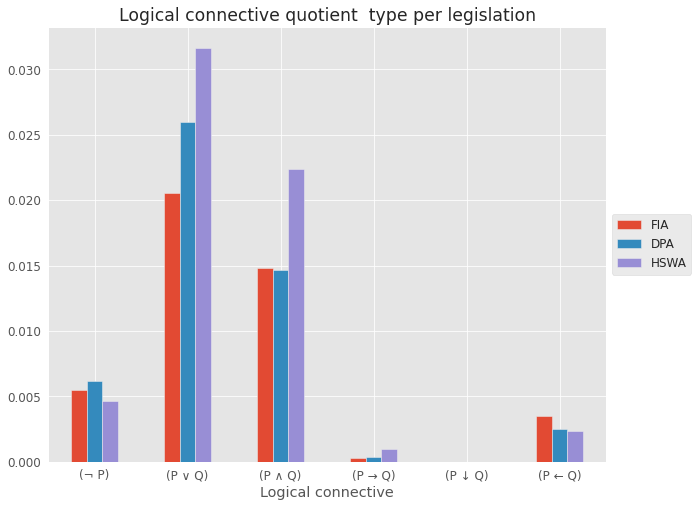

```python
# importing package
import matplotlib
import matplotlib.pyplot as plt
import pandas as pd
import seaborn as sns
sns.set_style("dark")

matplotlib.style.use('ggplot')
font = {'family' : 'normal',
        'weight' : 'normal',
        'size'   : 12}
matplotlib.rc('font', **font)

# create data
df = pd.DataFrame([['(¬ P)', FIA_NEG_quotient , DPA_NEG_quotient , HSWA_NEG_quotient ], ['(P ∨ Q)', FIA_DSJ_quotient , DPA_DSJ_quotient , HSWA_DSJ_quotient ], ['(P ∧ Q)', FIA_CNJ_quotient , DPA_CNJ_quotient , HSWA_CNJ_quotient ],
                   ['(P → Q)', FIA_MIMP_quotient , DPA_MIMP_quotient , HSWA_MIMP_quotient ],['(P ↓ Q)', FIA_JD_quotient , DPA_JD_quotient , HSWA_JD_quotient ],['(P ← Q)', FIA_CIMP_quotient , DPA_CIMP_quotient , HSWA_CIMP_quotient ]],
                  columns=['Logical connective', 'FIA', 'DPA', 'HSWA'])
# view data
print(df)

# pandas plot grouped bar chart
df.plot(x='Logical connective',
        figsize=(10,8),
        kind='bar',
        rot=0,
        stacked=False,
        title='Logical connective quotient  type per legislation')

plt.legend(loc='center left', bbox_to_anchor=(1.0, 0.5))
#add df.plot(grid=True)?

plt.savefig("fiadpahswa.pdf")
```

**7.2 Significant difference test**

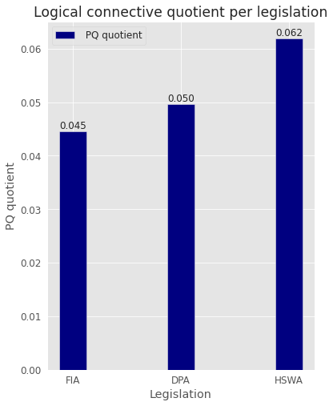

```python
#!/usr/bin/env python
# a bar plot with errorbars
import numpy as np
import matplotlib.pyplot as plt

data = [("FIA", FIA_total_quotient), ("DPA", DPA_total_quotient), ("HSWA", HSWA_total_quotient)]
names, values = zip(*data)
# names = [x[0] for x in data]  # These two lines are equivalent to the the zip-command.
# values = [x[1] for x in data] # These two lines are equivalent to the the zip-command.

ind = np.arange(len(data))  # the x locations for the groups
width = 0.25    # the width of the bars

fig, ax = plt.subplots(figsize=(6,8))
rects = ax.bar(ind, values, width, color='navy', label=" PQ quotient")


# add some text for labels, title and axes ticks
ax.set_ylabel('PQ quotient')
ax.set_xlabel('Legislation')
ax.set_title('Logical connective quotient per legislation')
ax.legend()
#ax.legend(loc="upper center", bbox_to_anchor=(0.5, 1.15), ncol=2)
ax.set_xticks(ind)
ax.set_xticklabels(names)




def autolabel(rects):
    """Attach a text label above each bar in *rects*, displaying its height."""
    for rect in rects:
        height = rect.get_height()
        ax.annotate(f'{rect.get_height():0.3f}',
                    xy=(rect.get_x() + rect.get_width() / 2, height),
                    xytext=(0, 0),  # 3 points vertical offset
                    textcoords="offset points",
                    ha='center', va='bottom')


autolabel(rects)

plt.savefig("fiadpahswa_lcq.pdf")

plt.show()
```

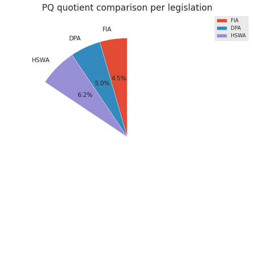

```python
import pandas as pd
import matplotlib.pyplot as plt

df4 = pd.DataFrame({"legislation":["FIA", "DPA","HSWA"],
                    "quotient":[FIA_total_quotient, DPA_total_quotient, HSWA_total_quotient]})

_, ax = plt.subplots(figsize = (9,9))
wedges,_,_ = ax.pie(df4["quotient"]
                    ,labels=df4["legislation"]
                    ,shadow=False,startangle=90, autopct="%1.1f%%"
                    ,textprops={'fontsize': 12})
ax.legend(wedges,df4["legislation"], loc='upper right', ncol=1, prop={'size': 10});

plt.title("PQ quotient comparison per legislation")
```

```python
# Friedman test
from numpy.random import seed
from numpy.random import randn
from scipy.stats import friedmanchisquare
# seed the random number generator
seed(1)
# generate three independent samples
data1 = [FIA_NEG_quotient, FIA_DSJ_quotient, FIA_CNJ_quotient, FIA_MIMP_quotient, FIA_JD_quotient, FIA_CIMP_quotient]
data2 = [DPA_NEG_quotient, DPA_DSJ_quotient, DPA_CNJ_quotient, DPA_MIMP_quotient, DPA_JD_quotient, DPA_CIMP_quotient]
data3 = [HSWA_NEG_quotient, HSWA_DSJ_quotient, HSWA_CNJ_quotient, HSWA_MIMP_quotient, HSWA_JD_quotient, HSWA_CIMP_quotient]
# compare samples
stat, p = friedmanchisquare(data1, data2, data3)
print('Statistics=%.3f, p=%.3f' % (stat, p))
# interpret
alpha = 0.05
if p > alpha:
	print('No statistically significant difference (accept H0)')
else:
	print('Statistically significant difference (Ha holds true reject H0')
```

```
Statistics=0.400, p=0.819
No statistically significant difference (accept H0)
```

**7.3 Conclusion**